# AS03_Homework_Data-Manipulation

B10610017 劉宇凡

2024/03/18

# 作業目的

這份作業希望能夠讓你熟悉操作資料的流程，利用這兩週所學的 `filter()`, `mutate()`, `select()`, `group_by()`, `summarize()`, `spread()`, `gather()` (或是 `pivot_wider()` 跟 `pivot_longer()` ) 等動詞完成任務。請一律印出 tibble，你可以利用 `as_tibble()` 將 dataframe 轉換成 tibble。

# 剖析歷年電力資料

資料介紹：這份資料來自[經濟部能源局的電力供給月資料](https://data.gov.tw/dataset/112650)，內容是2004年到2024年1月電力供給類別與發電量資料。

因為僅需觀察「全國發電量」，因此已經幫你將非「全國發電量」（如台電發電、民營電廠等）與「總計」相關的欄位濾掉，留下「全國發電量」的各個欄位

```r
library(tidyverse)

options(scipen = 999) #調整數字顯示，不要顯示科學記號

df_elec <- read_csv("data/經濟部能源署_電力供給月資料.csv") %>%
  mutate(
    ym_time =  as.character(`日期(年/月)`),
  ) %>%
  select(-單位, -`日期(年/月)`) %>% select(ym_time, 抽蓄水力=全國發電量_抽蓄水力, 火力_燃煤=全國發電量_火力_燃煤, 火力_燃油=全國發電量_火力_燃油, 火力_燃氣=全國發電量_火力_燃氣, 核能=全國發電量_核能, 再生能源_慣常水力=全國發電量_再生能源_慣常水力, 再生能源_地熱=全國發電量_再生能源_地熱, 再生能源_太陽光電=全國發電量_再生能源_太陽光電, 再生能源_風力=全國發電量_再生能源_風力, 再生能源_生質能=全國發電量_再生能源_生質能, 再生能源_廢棄物=全國發電量_再生能源_廢棄物)

### 給你看資料長這樣
df_elec %>% head(5)
```

```
#> # A tibble: 5 × 12
#>   ym_time 抽蓄水力 火力_燃煤 火力_燃油 火力_燃氣  核能 再生能源_慣常水力
#>   <chr>      <dbl>     <dbl>     <dbl>     <dbl> <dbl>             <dbl>
#> 1 200501      303.     9471.      825.     2341. 3726.              186.
#> 2 200502      290.     8235.      851.     1693. 3192.              236.
#> 3 200503      332.     9879.      841.     2512. 3223.              457.
#> 4 200504      332.     9514.     1035.     3161. 3138.              392.
#> 5 200505      342.    10316.     1599.     3715. 3390.              366.
#> # ℹ 5 more variables: 再生能源_地熱 <dbl>, 再生能源_太陽光電 <dbl>,
#> #   再生能源_風力 <dbl>, 再生能源_生質能 <dbl>, 再生能源_廢棄物 <dbl>
```

## 清理資料：學習長表格轉換

請將 `df_elec` 轉成長表格，發電類別儲存到 `elec`，發電量值儲存到 `power`。

進行完上述三步驟後，將結果儲存到 `df_elec_longer` 中，並印出**後五列**。

> 參考答案與做法: `gather()` or `pivot_longer()`

```r
### your code
# pivot_longer()
df_elec_longer <- df_elec %>%
    pivot_longer(cols = -ym_time, names_to = "elec", values_to = "power")

tail(df_elec_longer, 5)

# gather()
df_elec_longer <- df_elec %>%
    gather(key = "elec", value = "power", -ym_time)

tail(df_elec_longer, 5)

## result
```

[output not shown]

```
#> # A tibble: 5 × 3
#>   ym_time elec                power
#>   <chr>   <chr>               <dbl>
#> 1 202401  再生能源_地熱        2.46
#> 2 202401  再生能源_太陽光電  831.
#> 3 202401  再生能源_風力     1002.
#> 4 202401  再生能源_生質能     22.4
#> 5 202401  再生能源_廢棄物    295.
#> # A tibble: 5 × 3
#>   ym_time elec            power
#>   <chr>   <chr>           <dbl>
#> 1 202309  再生能源_廢棄物  283.
#> 2 202310  再生能源_廢棄物  266.
#> 3 202311  再生能源_廢棄物  225.
#> 4 202312  再生能源_廢棄物  252.
#> 5 202401  再生能源_廢棄物  295.
```

## 資料正規化

使用`separate()`函式將`df_elec_longer`變數中的`elec`電力種類欄位以「_」拆開成`elec_category`與`elec_subcategory`兩個欄位。 例如：`elec`欄位中的「火力_燃煤」，被拆分後的結果：`elec_category`為「火力」、`elec_subcategory`為「燃煤」。 此外，若無法拆分的電力種類，`elec_category`與`elec_subcategory`則都填入相同的值。 例如：`elec`欄位中的「核能」，被拆分後的結果：`elec_category`為「核能」、`elec_subcategory`為「核能」。

並將結果儲存至`df_elec_longer_clean`當中，將最後三列印出。

> 參考做法與提示：這題有很多種做法，可以直接使用separate()函數，separate()函數內有三個重要的參數：「data=欲拆分的欄位, into=拆分後的欄位, sep=以什麼字元為基準拆分」。當然你也可以使用其他方法。

> 參考做法與提示：可搭配if_else()函數。

```r
### your code
df_elec_longer_clean <- df_elec_longer %>%
    separate(elec, into = c("elec_category", "elec_subcategory"), sep = "_", fill = "right") %>%
    mutate(elec_subcategory = if_else(is.na(elec_subcategory), elec_category, elec_subcategory))

tail(df_elec_longer_clean, 3)

# result
```

[output not shown]

```
#> # A tibble: 3 × 4
#>   ym_time elec_category elec_subcategory power
#>   <chr>   <chr>         <chr>            <dbl>
#> 1 202311  再生能源      廢棄物            225.
#> 2 202312  再生能源      廢棄物            252.
#> 3 202401  再生能源      廢棄物            295.
```

## 處理時間資料：str_sub()

你應該有注意到，這個資料有`ym_time`的欄，我們希望能把它弄成更好分析的格。所以接下來，請你使用`str_sub()`將`ym_time`這個欄位分成*年*與*月* 年分，命名為`year`；月份命名為`month`。(請使用上一小題正規化後的資料`df_elec_longer_clean`)

並將結果儲存至`df_elec_longer_clean_time`當中，將前三列印出。

```r
df_elec_longer_clean_time <- df_elec_longer_clean %>%
    mutate(year = str_sub(ym_time, start = 1, end = 4),
           month = str_sub(ym_time, start = 5, end = 6))

head(df_elec_longer_clean_time, 3)

# result
```

[output not shown]

```
#> # A tibble: 3 × 6
#>   ym_time elec_category elec_subcategory power year  month
#>   <chr>   <chr>         <chr>            <dbl> <chr> <chr>
#> 1 200501  抽蓄水力      抽蓄水力          303. 2005  01
#> 2 200502  抽蓄水力      抽蓄水力          290. 2005  02
#> 3 200503  抽蓄水力      抽蓄水力          332. 2005  03
```

## 資料排序

現在我想知道2020年到2024年，**再生能源**發電量佔比前三高的時間點、電力種類`elec_subcategory`。

請使用`arrange()`進行排序，將排序好的資料存到`df_elec_longer_clean_time_renew`，並印出前三列

```r
df_elec_longer_clean_time_renew <- df_elec_longer_clean_time %>%
    mutate(year = as.numeric(year)) %>%
    filter(elec_category == "再生能源" & year >= 2020 & year <= 2024) %>%
    arrange(desc(power))

head(df_elec_longer_clean_time_renew, 3)

# result
```

[output not shown]

```
#> # A tibble: 3 × 6
#>   ym_time elec_category elec_subcategory power  year month
#>   <chr>   <chr>         <chr>            <dbl> <dbl> <chr>
#> 1 202309  再生能源      太陽光電         1363.  2023 09
#> 2 202307  再生能源      太陽光電         1337.  2023 07
#> 3 202308  再生能源      太陽光電         1227.  2023 08
```

## 電力種類與年平均發電量交叉比對

現在我們有了時間`year`與`month`與電力種類`elec_category`，接下來想請你使用`df_elec_longer_clean_time`計算出每個發電種類(請使用`elec_category`欄位)的**年平均發電量**，命名為`yearly_avg`，並將資料儲存至`df_elec_yearly_avg`中，印出前三列。

因為2024年的資料只有到1月，所以請記得先篩掉2024年的資料

提示：可以使用`group_by()`與`summarize()`

```r
df_elec_yearly_avg <- df_elec_longer_clean_time %>%
    filter(year != 2024) %>%
    group_by(elec_category, year) %>%
    summarize(yearly_avg = mean(power)) %>%
    arrange(desc(elec_category))

head(df_elec_yearly_avg, 3)

# result
```

[output not shown]

```
#> # A tibble: 3 × 3
#> # Groups:   elec_category [1]
#>   elec_category year  yearly_avg
#>   <chr>         <chr>      <dbl>
#> 1 火力          2005       4893.
#> 2 火力          2006       5111.
#> 3 火力          2007       5287.
```

## 資料視覺化

請你用`df_elec_yearly_avg`畫出所有電力種類`elec_category`2005到2023年的平均發電量`yearly_avg`bar圖。

結果要有四張圖，請用for迴圈來畫，因為以後可能遇到類別更多的時候，基本圖請參考notion，有興趣可以改顏色、字體等..。

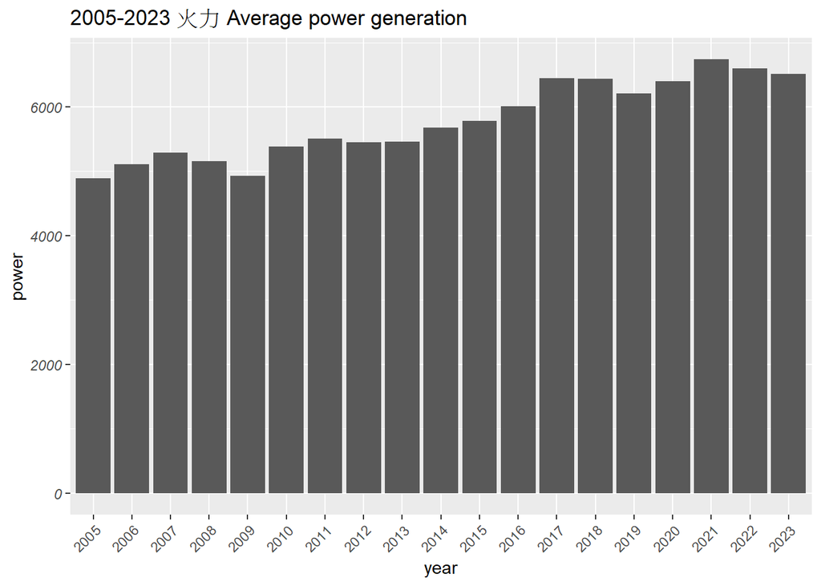

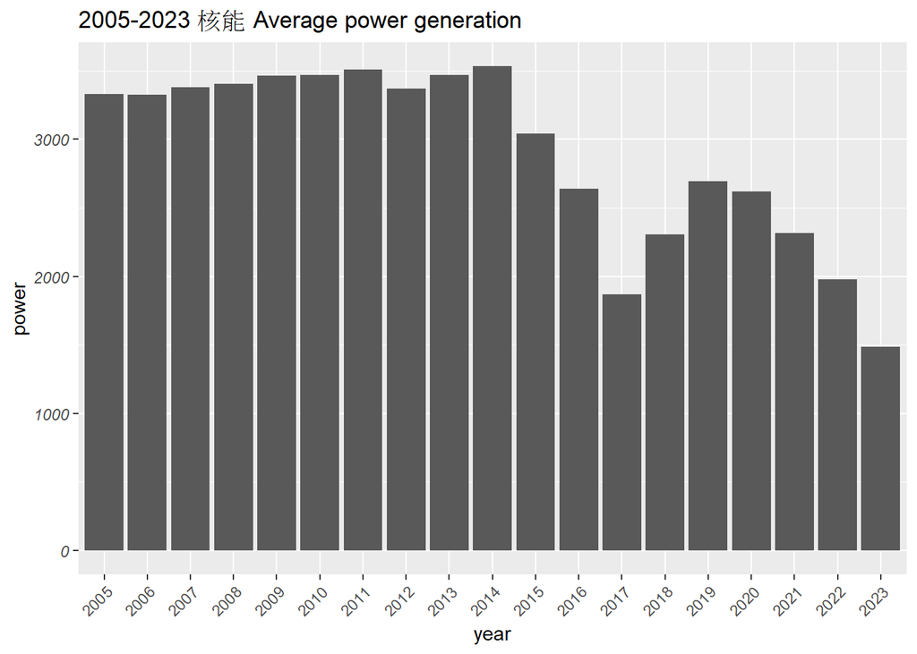

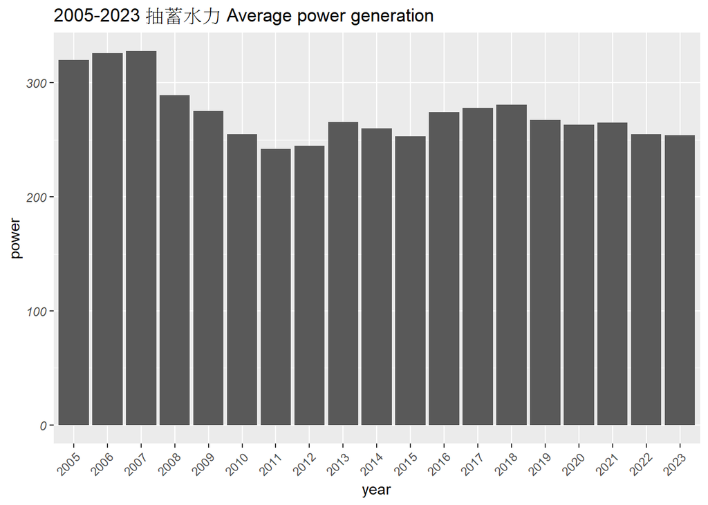

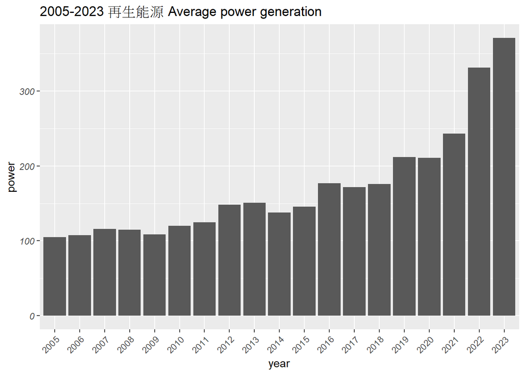

```r
library(ggplot2)
# 提取發電種類
categories <- unique(df_elec_yearly_avg$elec_category)

# 創建空的清單來存儲圖形
plots <- list()

# 使用 for 迴圈繪製每個發電種類每年平均發電量的長條圖
for (category in categories) {
  category_data <- df_elec_yearly_avg[df_elec_yearly_avg$elec_category == category, ]
  plot <- ggplot(category_data, aes(x = year, y = yearly_avg)) +
    geom_col() +
    labs(title = paste("2005-2023", category, "Average power generation"),
         x = "year",
         y = "power") +
    theme(axis.text.x = element_text(angle = 45, hjust = 1),
          axis.text.y = element_text(face = "italic"))

  plots[[category]] <- plot
}

# 顯示四張圖
for (i in 1:length(plots)) {
  print(plots[[i]])
}
```

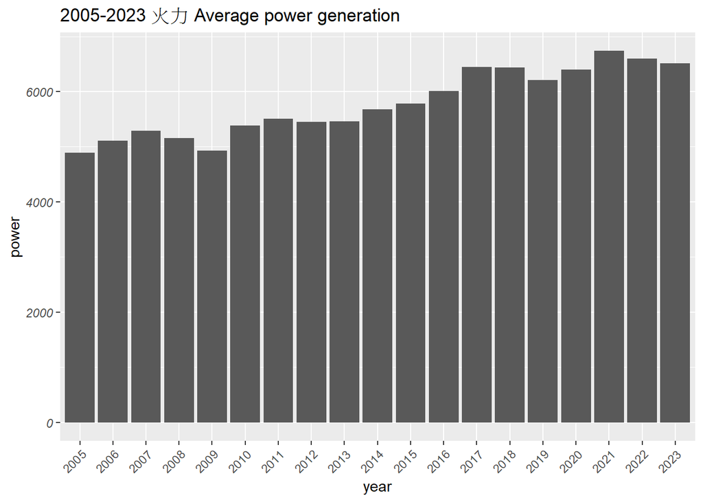

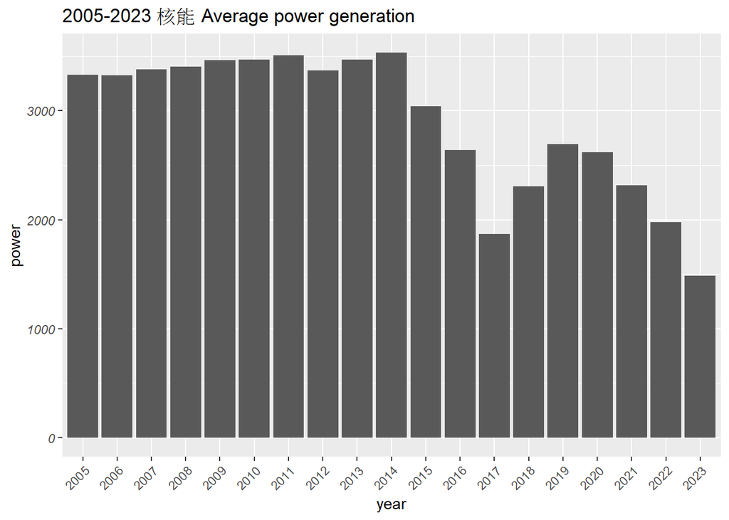

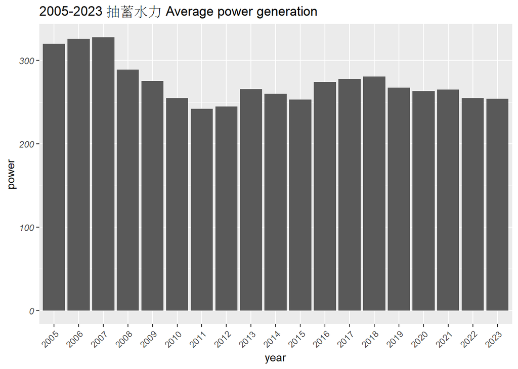

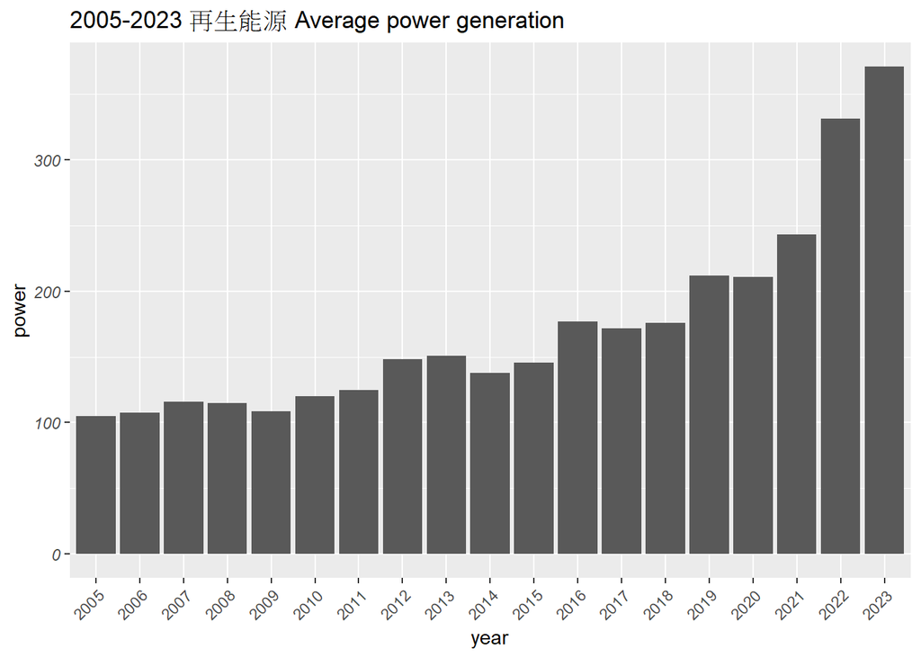

```r
# 提取發電種類
categories <- unique(df_elec_yearly_avg$elec_category)

# 使用 ggplot() 繪製每個發電種類每年平均發電量的長條圖
plots <- lapply(categories, function(category) {
  category_data <- df_elec_yearly_avg %>%
    filter(elec_category == category)

  ggplot(category_data, aes(x = year, y = yearly_avg)) +
    geom_col() +
    labs(title = paste("2005-2023", category, "Average power generation"),
         x = "year",
         y = "power") +
    theme(axis.text.x = element_text(angle = 45, hjust = 1),
          axis.text.y = element_text(face = "italic"))
})

# 使用 for 顯示四張圖
for (i in 1:length(plots)) {
  print(plots[[i]])
}
```

## 用資料說故事

上一題已經知道各類能源從2005年到現在的發電量趨勢。所以請利用上一題視覺化的資料，告訴我你觀察到的東西，這題沒有標準答案。

#### Answer上面的圖我想說：

從y軸年平均發電量的數值大小可得知，火力、核能為臺灣長期以來主要的發電種類。但若從x軸的時間趨勢則可觀察到，核能的年平均發電量在2014年後就逐漸減少，2023年的平均發電量大約只有2005年的一半。相較之下，火力的年平均發電量則有增加的趨勢，從2005年的5000(power)左右增加至2023年的6000(power)以上，並且為佔比最高的發電種類。

至於發電量較小的抽蓄水力及再生能源則可看出，水力的年均發電量在2011年之後，就不太有減少的趨勢，每年穩定提供約250～300(power)。再生能源的年均發電量則是在2014年後逐漸增加，2023年的發電量已經超過300(power)，是2005年的3倍以上，正好與核能的趨勢呈現交叉關係。

推測這樣的現象與政府提出的「非核家園」政策有關，藉著提高其他發電種類，填補核能減少的發電量，而再生能源是近幾年來具有潛力的發電能源。因此，其年平均發電量的增加幅度更為顯著。

## 預學作業

這周的作業有請大家使用str_sub()處理時間資料，但所以每個不同的程式語言其實都會有一套處理時間的物件與函式。透過此作業，你將學會如何在R語言中有效地處理和操作時間資料。

1. 請從ChatGPT得知，R的時間物件為何？

在 R 語言中，時間物件通常使用 POSIXct 或 POSIXlt 類型來表示。這些類型可以表示日期和時間，包括時區信息。POSIXct 是以從 1970 年 1 月 1 日至今的秒數來表示時間的方式，而 POSIXlt 則是以年、月、日、時、分、秒等元件來表示。您可以使用不同的函數來創建這些時間物件，如 as.POSIXct() 和 as.POSIXlt()。

2. Lubridate這個套件的功能是什麼？lubridate他可以做什麼事情？

lubridate 是 R 語言中一個用於處理日期和時間的套件，它提供了許多方便的函數和工具，使得日期和時間的解析、操作和可視化變得更加容易。lubridate 主要提供了以下功能：

1. 日期時間的創建與解析：lubridate 提供了 ymd()、mdy()、dmy() 等函數，用於從文字格式解析日期，並將其轉換為 R 語言中的日期時間物件。
2. 日期時間的提取：您可以使用 year()、month()、day()、hour()、minute()、second() 等函數來從日期時間物件中提取年、月、日、時、分、秒等元件。
3. 日期時間的操作：lubridate 提供了方便的算術運算符，您可以對日期時間物件進行加減操作，如 +、-、%m+%、%m-% 等。
4. 時區的處理：lubridate 可以處理不同時區的日期時間，並提供了函數如 with_tz()、force_tz() 來處理時區相關的問題。
5. 日期時間的格式化輸出：使用 format() 函數可以將日期時間物件轉換為指定格式的文字表示形式。

(3)請ChatGPT教你，如何用lubridate的函式把ym_time這個變項轉為日期date變項、然後再用lubridate的函式把date轉為year、把date轉為month。

```r
library(dplyr)
library(lubridate)

df_elec_longer_clean_time <- df_elec_longer_clean %>%
  mutate(ym_time_str = as.character(ym_time),
         date = ymd(paste(ym_time_str, "19")),
         year = year(date),
         month = month(date))


df_elec_longer_clean_time_select <- df_elec_longer_clean_time %>%
    select(ym_time, elec_category, elec_subcategory, date, year, month)

tail(df_elec_longer_clean_time_select, 3)
```

```
#> # A tibble: 3 × 6
#>   ym_time elec_category elec_subcategory date        year month
#>   <chr>   <chr>         <chr>            <date>     <dbl> <dbl>
#> 1 202311  再生能源      廢棄物           2023-11-19  2023    11
#> 2 202312  再生能源      廢棄物           2023-12-19  2023    12
#> 3 202401  再生能源      廢棄物           2024-01-19  2024     1
```